# AidStream IATI Result Element Analysis for Netherland based Organisations

Anjesh

2019-03-22

TL;DR

A trimmed version of this analysis (without code) is published in [medium](https://blog.yipl.com.np/aidstream-result-data-analysis-for-netherlands-based-organisations-4240ca228a57).

# 1 Background

In this analysis, we are using all the `result` data of all the published activities of Netherlands (NL) based [publishers](https://iatiregistry.org/publisher).

For those new to IATI Standard, please refer to [Result page](http://reference.iatistandard.org/203/activity-standard/iati-activities/iati-activity/result/) to understand the content of `result` element.

# 2 Setup

First we need to load the required packages.

```r
library(glue)
library(RPostgreSQL)
library(tidyverse)
library(viridis)
library(lubridate)
library(jsonlite)
library(scales)
library(skimr)
library(gt)

cl.result.types <- read.csv(url("http://reference.iatistandard.org/203/codelists/downloads/clv1/codelist/ResultType.csv"), stringsAsFactors = FALSE)
cl.result.types.labels <- setNames(as.character(cl.result.types$name), cl.result.types$code)

cl.indicator.measures <- read.csv(url("http://reference.iatistandard.org/203/codelists/downloads/clv1/codelist/IndicatorMeasure.csv"))
cl.indicator.measures.labels <- setNames(as.character(cl.indicator.measures$name),
                                         cl.indicator.measures$code)

options(scipen = 999) # to show the numbers instead of scientific notations in ggplot2 graphs
options(warn = -1)
```

# 3 Data Preparation

## 3.1 Data Import

The following code imports necessary fields from the database. For simplicity, I saved the results from database to [RDS](https://stat.ethz.ch/R-manual/R-devel/library/base/html/readRDS.html) file and loaded from RDS file for quick import.

```r
knitr::opts_chunk$set(echo = TRUE)
organisations.all.rds <- here::here("aidstream","04-sessions","organisations.all.rds")
activities.all.rds <- here::here("aidstream","04-sessions","activities.all.rds")
results.all.rds <- here::here("aidstream","04-sessions","results.all.rds")

if(file.exists(organisations.all.rds) &
   file.exists(activities.all.rds) &
   file.exists(results.all.rds)) {
  df.organizations.all <- readRDS(organisations.all.rds)
  df.activities.all <- readRDS(activities.all.rds)
  df.results.all <- readRDS(results.all.rds)
  } else {
  dbconn <- dbConnect(dbDriver("PostgreSQL"),
                      host="localhost",
                      dbname="aidstream_prod_local",
                      user="postgres")
  fetch_query <- function(conn, query) {
    resultset <- dbSendQuery(conn, query)
    fetch(resultset, n=-1)
  }
  df.organizations.all <- fetch_query(dbconn, "select id, user_identifier, name, reporting_org, country,
                                  published_to_registry, created_at, updated_at
                                  from organizations where country='NL';")
  df.activities.all <- fetch_query(dbconn, glue("select id, identifier, title, organization_id,
                        activity_status, activity_date, recipient_country, recipient_region,
                        sector, published_to_registry,
                        created_at, updated_at
                        from activity_data where
                        published_to_registry = 1 and
                        organization_id in ({paste0(df.organizations.all$id, collapse=\",\")});"))
  df.results.all <- fetch_query(dbconn, glue("select id, activity_id, result, created_at
                           from activity_results where
                           activity_id in ({paste0(df.activities.all$id, collapse=\",\")});"))
  saveRDS(df.organizations.all, file=organisations.all.rds)
  saveRDS(df.activities.all, file=activities.all.rds)
  saveRDS(df.results.all, file=results.all.rds)
  }
df.summary <- df.results.all %>%
  left_join(df.activities.all, by=c("activity_id"="id")) %>%
  left_join(df.organizations.all, by=c("organization_id"="id"))
```

Total Organisations: 79

Total unique Activities: 901

## 3.2 Preparing `result` element

First we need to convert JSON string to R list before we can further process the data.

There can be multiple `indicator`s within a given `result` and multiple `baseline` and multiple `period` elements within an `indicator`. Lets extract the count of the indicators, baselines and periods mentioned inside each result element to see how many indicators, baselines and periods are reported under each result.

```r
results.rds <- here::here("aidstream","04-sessions","results.rds")
if(file.exists(results.rds)) {
  df.results <- readRDS(results.rds)
  } else {
    df.results.all <- df.results.all %>%
      mutate(result_json = map(result, fromJSON))
    get_indicator_count <- function(result_json) {
      return(nrow(result_json$indicator))
    }
    get_indicator_baseline_count <- function(result_json) {
      sum(map_int(result_json$indicator$baseline, nrow))
    }
    get_indicator_period_count <- function(result_json) {
      sum(map_int(result_json$indicator$period, nrow))
    }

    get_indicators <- function(result_json) {
      df <- data.frame(
        indicator_title = map_chr(result_json$indicator$title, function(.x) {
          .x$narrative[[1]]$narrative[1]
        }),
        indicator_measure = as.character(result_json$indicator$measure),
        indicator_ascending = as.character(result_json$indicator$ascending),
        stringsAsFactors = FALSE
      )
      df$baseline = result_json$indicator$baseline
      df$period = result_json$indicator$period
      df
    }

    df.results <- df.results.all %>%
      transmute(id, activity_id,
                result_title = map_chr(result_json, function(.x) {
                  .x$title$narrative[[1]]$narrative[1]
                }),
                result_type = map_chr(result_json, "type"),
                indicators_count = map_int(result_json, get_indicator_count),
                indicators_baseline_count = map_int(result_json, get_indicator_baseline_count),
                indicators_period_count = map_int(result_json, get_indicator_period_count),
                indicator = map(result_json, get_indicators)
      )
    saveRDS(df.results, file = results.rds)
    }
```

### 3.2.1 `Result` quick summary

```r
skim_with(integer = list(hist = NULL, p0=NULL, p25=NULL, p50=NULL, p75=NULL, p100=NULL),
          character = list(min = NULL, max = NULL))
df.results %>%
  select(starts_with("result")) %>%
  skim() %>%
  pander()
```

Skim summary statistics  
n obs: 7237  
n variables: 2

| variable | missing | complete | n | empty | n_unique |
| --- | --- | --- | --- | --- | --- |
| result_title | 5 | 7232 | 7237 | 0 | 3253 |
| result_type | 0 | 7237 | 7237 | 0 | 4 |

## 3.3 Preparing `indicator` sub-element

We create a new dataframe for `indicator`s only.

```r
df.indicators <- df.results %>%
  unnest(indicator)
```

### 3.3.1 `indicator` quick summary

```r
skim_with(integer = list(hist = NULL, p0=NULL, p25=NULL, p50=NULL, p75=NULL, p100=NULL))
df.indicators %>%
  select(indicator_measure, indicator_ascending, indicator_title,
         result_title, result_type) %>%
  skim() %>%
  pander()
```

Skim summary statistics  
n obs: 11179  
n variables: 5

| variable | missing | complete | n | empty | n_unique |
| --- | --- | --- | --- | --- | --- |
| indicator_ascending | 0 | 11179 | 11179 | 2432 | 5 |
| indicator_measure | 0 | 11179 | 11179 | 2 | 6 |
| indicator_title | 1 | 11178 | 11179 | 3 | 4723 |
| result_title | 5 | 11174 | 11179 | 0 | 3253 |
| result_type | 0 | 11179 | 11179 | 0 | 4 |

## 3.4 Preparing `baseline` and `period` sub-elements

Simiarly we prepare dataframes for `period`s and `baseline`s.

```r
get_baselines <- function(baseline_json) {
  df <- data.frame(
    baseline_year = as.character(baseline_json$year),
    baseline_value = as.character(baseline_json$value),
    baseline_comment = baseline_json$comment[[1]]$narrative[[1]]$narrative[1],
    stringsAsFactors = FALSE
  )
  df
}

get_periods <- function(period_json) {
  df <- data.frame(
    period_start = map_chr(period_json$period_start, "date"),
    period_end = map_chr(period_json$period_end, "date"),
    period_target = map_chr(period_json$target, "value"),
    period_actual = map_chr(period_json$actual, "value"),
    stringsAsFactors = FALSE
  )
  df
}

df.indicators <- df.indicators %>%
  mutate(baseline_df = map(baseline, get_baselines),
         period_df = map(period, get_periods))

df.baselines <- df.indicators %>%
  unnest(baseline_df)

df.periods <- df.indicators %>%
  unnest(period_df)

df.periods$period_start <- parse_date_time(df.periods$period_start, "y-m-d", tz = "GMT")
df.periods$period_end <- parse_date_time(df.periods$period_end, "y-m-d", tz = "GMT")
df.periods$period_target <- as.numeric(df.periods$period_target)
df.periods$period_actual <- as.numeric(df.periods$period_actual)
```

### 3.4.1 `baseline` quick summary

```r
skim_with(integer = list(hist = NULL, p0=NULL, p25=NULL, p50=NULL, p75=NULL, p100=NULL))
df.baselines %>%
  select(-ends_with("count"),-ends_with("id"), -baseline, -starts_with("period")) %>%
  skim() %>%
  pander(caption = "Baseline Summary")
```

Skim summary statistics  
n obs: 11179  
n variables: 8

| variable | missing | complete | n | empty | n_unique |
| --- | --- | --- | --- | --- | --- |
| baseline_comment | 9 | 11170 | 11179 | 9575 | 900 |
| baseline_value | 7 | 11172 | 11179 | 5365 | 450 |
| baseline_year | 0 | 11179 | 11179 | 5300 | 13 |
| indicator_ascending | 0 | 11179 | 11179 | 2432 | 5 |
| indicator_measure | 0 | 11179 | 11179 | 2 | 6 |
| indicator_title | 1 | 11178 | 11179 | 3 | 4723 |
| result_title | 5 | 11174 | 11179 | 0 | 3253 |
| result_type | 0 | 11179 | 11179 | 0 | 4 |

### 3.4.2 `period` quick summary

```r
skim_with(numeric = list(hist = NULL, p0=NULL, p25=NULL, p50=NULL, p75=NULL, p100=NULL, sd=NULL),
          POSIXct = list(median = NULL, min=NULL, max=NULL))
df.periods %>%
  select(-ends_with("count"),-ends_with("id")) %>%
  skim() %>%
  pander()
```

Skim summary statistics  
n obs: 15748  
n variables: 9

| variable | missing | complete | n | empty | n_unique |
| --- | --- | --- | --- | --- | --- |
| indicator_ascending | 0 | 15748 | 15748 | 3062 | 5 |
| indicator_measure | 0 | 15748 | 15748 | 2 | 6 |
| indicator_title | 1 | 15747 | 15748 | 3 | 4723 |
| result_title | 8 | 15740 | 15748 | 0 | 3253 |
| result_type | 0 | 15748 | 15748 | 0 | 4 |

| variable | missing | complete | n | mean |
| --- | --- | --- | --- | --- |
| period_actual | 5910 | 9838 | 15748 | 11856.91 |
| period_target | 6939 | 8809 | 15748 | 133389.73 |

| variable | missing | complete | n | n_unique |
| --- | --- | --- | --- | --- |
| period_end | 458 | 15290 | 15748 | 260 |
| period_start | 458 | 15290 | 15748 | 236 |

Now we can proceed with the analysis.

# 4 Data analysis

We see in `indicator` summary that there are 11179 `indicator`s mentioned in 7237 `result`s. There’s an average of 1.54 `indicator`s in a given `result`. Lets see which `result`s have large number of `indicator`s.

```r
df.results %>%
  group_by(indicators_count) %>%
  count() %>%
  ungroup() %>%
  gt() %>%
  cols_label(
     indicators_count = "Unique count of indicators in each <Result> element",
     n = "Count of Results containing the given number of indicators"
  ) %>%
  tab_style(
    style = cells_styles(
      text_size = px(12)
    ),
    locations = cells_data(
      columns = everything()
    )
  )
```

| Unique count of indicators in each <Result> element | Count of Results containing the given number of indicators |
| --- | --- |
| 1 | 5543 |
| 2 | 664 |
| 3 | 490 |
| 4 | 289 |
| 5 | 94 |
| 6 | 82 |
| 7 | 16 |
| 8 | 30 |
| 9 | 6 |
| 10 | 4 |
| 11 | 12 |
| 12 | 4 |
| 30 | 1 |
| 32 | 2 |

We can see that there are 2 `result` elements, that contains as many as 32 `indicator`s. That makes `result` very long and complex. But we see that majority of `result` elements contain one `indicator` only. Ideally a given result can have multiple relevant indicators.

There are activities which has number of `result` element with the same result metadata.

```r
get_identifier <- function(identifier_text) {
  id_json <- fromJSON(identifier_text)
  id_json$iati_identifier_text
}

df.results %>%
  group_by(result_title, activity_id) %>%
  count() %>%
  filter(n>1) %>%
  arrange(desc(n)) %>%
  ungroup() %>%
  head(10) %>%
  left_join(df.activities.all, by=c("activity_id"="id")) %>%
  left_join(df.organizations.all, by=c("organization_id"="id")) %>%
  mutate(iati_identifier = map_chr(identifier, get_identifier)) %>%
  select(name, iati_identifier, result_title, n) %>%
  group_by(name) %>%
  gt() %>%
  cols_label(
    iati_identifier = "IATI Identifier",
    result_title = "Result Title",
    n = "Number of Result element in a given activity"
  ) %>%
  cols_hide(
    columns = vars(activity_id)
  ) %>%
  tab_style(
    style = cells_styles(
      text_size = px(12)
    ),
    locations = cells_data(
      columns = everything()
    )
  )
```

| IATI Identifier | Result Title | Number of Result element in a given activity |
| --- | --- | --- |
| Solidaridad Netherlands |  |  |
| NL-KVK-51756811-SSEA-P1467 | (Output) Stakeholder dynamics generate dialogue & debate on sustainability or land issues (land rights) | 30 |
| CHOICE for Youth and Sexuality |  |  |
| NL-KVK-32108345-NLBB26-8842-ID | Goal 2. Adolescent girls and boys are meaningfully engaged to claim their SHR rights | 27 |
| NL-KVK-32108345-NLBB26-8845-MZ | Goal 2. Adolescent girls and boys are meaningfully engaged to claim their SHR rights | 22 |
| Rutgers |  |  |
| NL-KVK-41193594-GUS7140ET | Increased utilisation of comprehensive SRHR information and education by all people | 27 |
| NL-KVK-41193594-GUS7130ID | Increased utilisation of comprehensive SRHR information and education by all people | 23 |
| NL-KVK-41193594-GUS7135UG | Increased utilisation of comprehensive SRHR information and education by all people | 23 |
| NL-KVK-41193594-GUS7145KE | Increased utilisation of comprehensive SRHR information and education by all people | 23 |
| NL-KVK-41193594-GUS7150MW | Increased utilisation of comprehensive SRHR information and education by all people | 23 |
| NL-KVK-41193594-GUS7075GH-GUS7050GH | Increased utilisation of comprehensive SRHR information and education by all people | 23 |
| NL-KVK-41193594-GUS7120PK | Increased utilisation of comprehensive SRHR information and education by all people | 21 |

## 4.1 Number of `result` element based on `result/type`

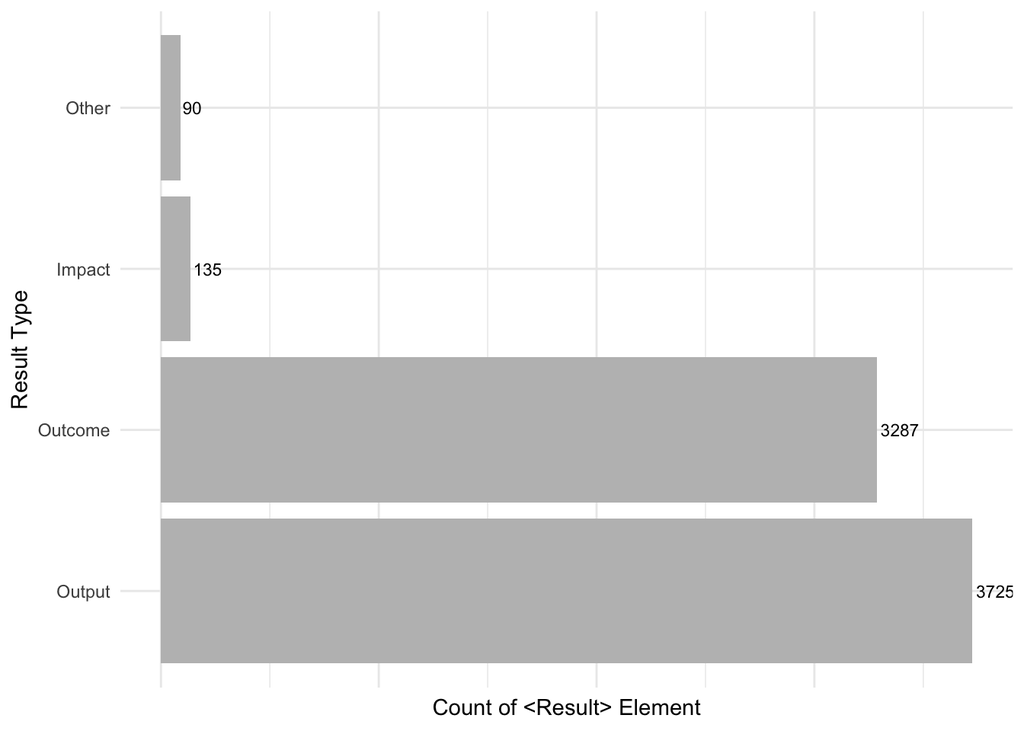

```r
df.results %>%
  group_by(result_type) %>%
  count() %>%
  select(result_type, n) %>%
  ggplot(aes(x=result_type, y=n)) +
  geom_bar(stat = "identity", fill="gray") +
  coord_flip() +
  scale_x_discrete(labels = cl.result.types.labels) +
  geom_text(aes(label=n), hjust=-0.1, size=3) +
  theme_minimal() +
  theme(axis.text.x = element_blank()) +
  labs(x="Result Type", y="Count of <Result> Element")
```

We see that most of the `result` are Output-based and Outcome-based in the published activities.

## 4.2 `indicator` subelement count based on `indicator/measure`

[`indicator/measure`](http://reference.iatistandard.org/203/activity-standard/iati-activities/iati-activity/result/indicator/#iati-activities-iati-activity-result-indicator-measure) defines the unit of measure in which the value is reported in the given indicator i.e. in [`baseline/value`](http://reference.iatistandard.org/203/activity-standard/iati-activities/iati-activity/result/indicator/baseline/) and values for [`period/target/value`](http://reference.iatistandard.org/203/activity-standard/iati-activities/iati-activity/result/indicator/period/target/) and `period/actual/value`.

```r
df.indicators %>%
  group_by(indicator_measure) %>%
  count() %>%
  ungroup() %>%
  mutate(label = cl.indicator.measures.labels[indicator_measure]) %>%
  select(indicator_measure, label, n) %>%
  mutate(label = replace_na(label,"-")) %>%
  gt() %>%
  cols_label(
    label = "Indicator Measure",
    n = "Count of <indicator> sub-element"
  ) %>%
  cols_hide(
    columns = vars(indicator_measure)
  ) %>%
  tab_footnote(
    footnote = "Missing indicator-measure in <indicator>",
    locations = cells_data(
      columns = vars(label),
      rows = label == "-"
    )
  ) %>%
  tab_style(
    style = cells_styles(
      text_size = px(12)
    ),
    locations = cells_data(
      columns = everything()
    )
  )
```

| Indicator Measure | Count of <indicator> sub-element |
| --- | --- |
| -<sup>1</sup> | 2 |
| Unit | 9586 |
| Percentage | 1559 |
| Nominal | 10 |
| Ordinal | 7 |
| Qualitative | 15 |

<sup>*1*</sup> Missing indicator-measure in <indicator>

We see that most of the `indicator/measure` are of quantitative nature i.e. Unit and Percentage. There are 5 defined codes for [`indicator/measure`](http://reference.iatistandard.org/203/codelists/IndicatorMeasure/). There’s missing value for `indicator/measure` as well.

## 4.3 `result/type` vs `indicator/measure`

Lets see what `indicator/measure`s are used for each `result/type`.

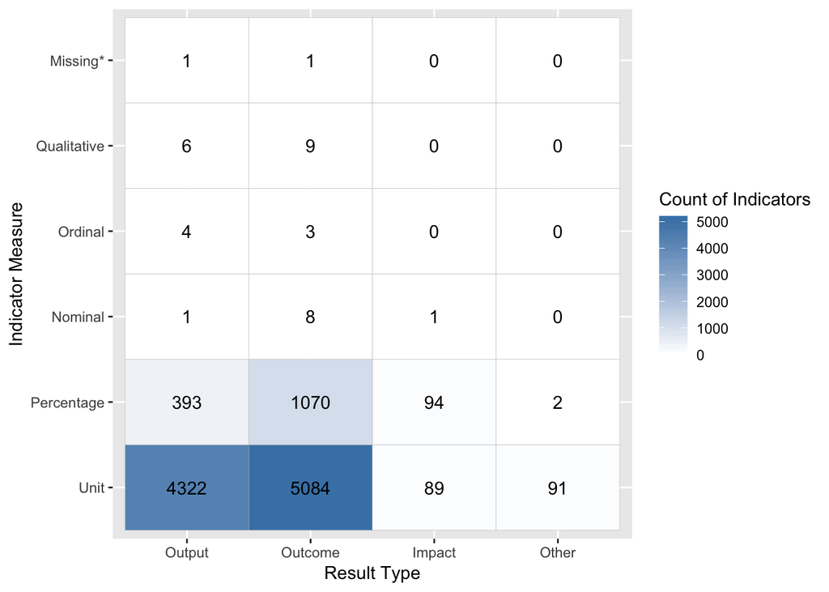

```r
df.indicators %>%
  group_by(result_type, indicator_measure) %>%
  count() %>%
  spread(indicator_measure, n, fill=0) %>%
  gather(indicator_measure, n, -result_type) %>%
  ggplot(aes(x=result_type, y=indicator_measure)) +
  geom_tile(aes(fill=n), colour = "gray") +
  geom_text(aes(label=n)) +
  scale_x_discrete(labels = cl.result.types.labels) +
  scale_y_discrete(labels = c(cl.indicator.measures.labels, V1="Missing*")) +
  scale_fill_gradient(low = "white", high = "steelblue") +
  labs(x="Result Type", y="Indicator Measure", fill="Count of Indicators")
```

## 4.4 Exploring `baseline` element

### 4.4.1 Number of `baseline`s reported by `baseline/year`

```r
df.baselines %>%
  group_by(baseline_year) %>%
  count() %>%
  ungroup() %>%
  gt() %>%
  cols_label(
    baseline_year = "Baseline Year",
    n = "Number of baselines reported for that year"
  ) %>%
  tab_style(
    style = cells_styles(
      text_size = px(12)
    ),
    locations = cells_data(
      columns = everything()
    )
  )
```

| Baseline Year | Number of baselines reported for that year |
| --- | --- |
|  | 5300 |
| 2010 | 5 |
| 2011 | 7 |
| 2012 | 37 |
| 2013 | 180 |
| 2014 | 35 |
| 2015 | 258 |
| 2016 | 3581 |
| 2017 | 1244 |
| 2018 | 474 |
| 2019 | 19 |
| 2020 | 38 |
| 217 | 1 |

We see that there are few issues with the year as well like 217. Lets identify which organisation published 217 year in their `result/indicator/baseline` data.

```r
df.baselines %>%
  filter(indicator_measure==1 & baseline_year == 217) %>%
  select(activity_id) %>%
  left_join(df.activities.all, by=c("activity_id"="id")) %>%
  left_join(df.organizations.all, by=c("organization_id"="id")) %>%
  mutate(iati_identifier = fromJSON(identifier)$iati_identifier_text) %>%
  select(name, iati_identifier) %>%
  gt() %>%
  cols_label(
    name = "Organisation",
    iati_identifier = "IATI Identifier"
  ) %>%
  tab_style(
    style = cells_styles(
      text_size = px(12)
    ),
    locations = cells_data(
      columns = everything()
    )
  )
```

| Organisation | IATI Identifier |
| --- | --- |
| War Child Holland | NL-KVK-41215393-PJ3516 |

http://preview.iatistandard.org/index.php?url=https%3A//aidstream.org/files/xml/warchildholland-activities.xml shows 217 in the data.

### 4.4.2 Exploring Unit Quantitative `baseline/value`s

For simplicity, we will explore the `baseline/value` for unit `indicator/measure` only. As per standard, `baseline/value` is mandatory for quantiative `indicator/measure` i.e. for both Unit[1] and Percentage[2].

Lets see how many `baseline/value` are present.

```r
df.baselines %>%
  filter(indicator_measure==1) %>%
  group_by(baseline_value) %>%
  count() %>%
  mutate(baseline_value_present = ifelse(trimws(baseline_value)=="" | is.na(baseline_value),FALSE,TRUE)) %>%
  group_by(baseline_value_present) %>%
  summarize(n=sum(n)) %>%
  ungroup() %>%
  mutate(Percentage = round(100*n/sum(n), digits=2)) %>%
  gt() %>%
  cols_label(
    baseline_value_present = "Baseline value present?",
    n = "Count of baseline value",
  ) %>%
  tab_style(
    style = cells_styles(
      text_size = px(12)
    ),
    locations = cells_data(
      columns = everything()
    )
  )
```

| Baseline value present? | Count of baseline value | Percentage |
| --- | --- | --- |
| FALSE | 4920 | 51.32 |
| TRUE | 4666 | 48.68 |

### 4.4.3 `baseline/@value` type

We see only 48% of the reported `baseline/value` are present for Unit measure. Now we need to see if all those reported values are numeric or not. These values should be numeric as per [standard](http://reference.iatistandard.org/203/activity-standard/iati-activities/iati-activity/result/indicator/baseline/).

> The @value must be included for non-qualitative measures. The @value should be a valid number for all non-qualitative measures.

```r
df.baselines %>%
  filter(indicator_measure==1) %>%
  group_by(baseline_value) %>%
  count() %>%
  filter(baseline_value !="") %>%
  mutate(baseline_value_number = as.numeric(baseline_value)) %>%
  mutate(baseline_value_type = ifelse(is.na(baseline_value_number),"Text","Number")) %>%
  group_by(baseline_value_type) %>%
  summarise(n=sum(n)) %>%
  ungroup() %>%
  gt() %>%
  cols_label(
    baseline_value_type = "Baseline Value Type",
    n = "Count of Baseline Value",
  ) %>%
  tab_style(
    style = cells_styles(
      text_size = px(12)
    ),
    locations = cells_data(
      columns = everything()
    )
  )
```

| Baseline Value Type | Count of Baseline Value |
| --- | --- |
| Number | 4635 |
| Text | 31 |

We see that there are 31 instances where `baseline/value` are mentioned in textual form.

#### 4.4.3.1 `baseline/value` vs `baseline/year`

Lets plot the `baseline/value` against `baseline/year` and for Unit quantitative measure only i.e. `indicator-measure` = 1[Unit].

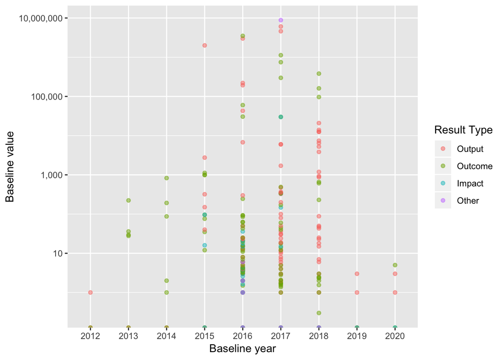

```r
df.baselines %>%
  filter(indicator_measure==1 & baseline_year != 217) %>%
  group_by(baseline_value, baseline_year, result_type) %>%
  count() %>%
  filter(baseline_value !="") %>%
  mutate(baseline_value_number = as.numeric(baseline_value)) %>%
  mutate(baseline_value_type = ifelse(is.na(baseline_value_number),"Text","Number")) %>%
  filter(baseline_value_type == "Number") %>%
  ungroup() %>%
  mutate(result_type = factor(cl.result.types.labels[result_type], levels = cl.result.types.labels)) %>%
  ggplot(aes(x=baseline_year,y=baseline_value_number, color=result_type)) +
  geom_point(alpha = 0.5) +
  scale_y_log10(label=comma) +
  labs(x="Baseline year", y = "Baseline value", color="Result Type")
```

The log10 scale was used as the `baseline/value` ranges from 0 to 10,000,000. It’s not clear whether we can have future `baseline/value`, but apparently there are `baseline/value` for 2019 and 2020.

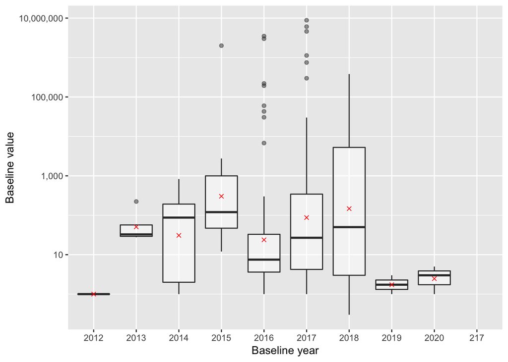

```r
df.baselines %>%
  filter(indicator_measure==1) %>%
  group_by(baseline_value, baseline_year, result_type) %>%
  count() %>%
  filter(baseline_value !="") %>%
  mutate(baseline_value_number = as.numeric(baseline_value)) %>%
  mutate(baseline_value_type = ifelse(is.na(baseline_value_number),"Text","Number")) %>%
  filter(baseline_value_type == "Number") %>%
  ungroup() %>%
  mutate(result_type = factor(cl.result.types.labels[result_type], levels = cl.result.types.labels)) %>%
  ggplot(aes(x=baseline_year,y=baseline_value_number)) +
  geom_boxplot(alpha=0.5) +
  scale_y_log10(label=comma) +
  stat_summary(fun.y=mean,shape=4,color='red',geom='point') +
  labs(x="Baseline year", y = "Baseline value", color="Result Type")
```

#### 4.4.3.2 High value `baseline/value` result

There are few `baseline/@value` beyond 1,000,000. Lets list those values. It would help the organisations to verify and correct those large numbers if those are typos.

```r
df.baselines %>%
  filter(indicator_measure==1) %>%
  mutate(baseline_value_number = as.numeric(baseline_value)) %>%
  filter(baseline_value_number >1000000) %>%
  select(result_title, indicator_title, baseline_comment, baseline_value) %>%
  mutate(baseline_value = as.numeric(baseline_value)) %>%
  arrange(desc(baseline_value)) %>%
  gt() %>%
  cols_label(
    result_title = "Result Title",
    indicator_title = "Indicator Title",
    baseline_comment = "Baseline Comment",
    baseline_value = "Baseline Value"
  ) %>%
  fmt_number(
    columns = vars(baseline_value),
    decimals = 0
  ) %>%
  tab_style(
    style = cells_styles(
      text_size = px(12)
    ),
    locations = cells_data(
      columns = everything()
    )
  )
```

| Result Title | Indicator Title | Baseline Comment | Baseline Value |
| --- | --- | --- | --- |
| Reach: Membership of Trade Unions directly supported(OP3) | Membership male and female (DO31 + DO32) | 2017 is start year of working with ToCs in new sectors and a new geographical focus of Mondiaal FNV | 8,830,024 |
| Number of people about which the study results are valid: 6,072,449 | Number of people about which the study results are valid: 6,072,449 |  | 6,072,449 |
| Number of people about which the study results are valid: 4,600,000 | Number of people about which the study results are valid: 4,600,000 |  | 4,600,000 |
| Outcome- Program Progress (MYP 2016-2020) | Area where trained practices are applied either on farmland or in protection area (hectares) |  | 3,500,000 |
| Output - Program Progress (MYP 2016-2020) | Volume of sustainably produced production |  | 3,000,000 |
| Output- Program Progress (MYP 2016-2020) | Volume of sustainably produced production (MT) | FEFAC Guidelines, RTRS or equivalent | 2,000,000 |
| I01. Access to safe water | I1 - Number of people having access to safe water | Baseline amount shows the number of people who already have access to safe water before the start of the project. Tha target value only shows the additional number of people targeted. | 1,125,845 |

These could be correct numbers, but it would be good to verify the big numbers at least once.

## 4.5 Exploring `period` element

```r
df.periods %>%
  filter(indicator_measure != "") %>%
  mutate(indicator_measure = paste0(indicator_measure, "-", cl.indicator.measures.labels[indicator_measure])) %>%
  mutate(result_type = paste0(result_type, "-", cl.result.types.labels[result_type])) %>%
  janitor::tabyl(result_type, indicator_measure) %>%
  janitor::adorn_totals(c("col","row")) %>%
  gt() %>%
  cols_label(
    result_type =  "Result Type"
  )
```

| Result Type | 1-Unit | 2-Percentage | 3-Nominal | 4-Ordinal | 5-Qualitative | Total |
| --- | --- | --- | --- | --- | --- | --- |
| 1-Output | 5511 | 731 | 1 | 4 | 6 | 6253 |
| 2-Outcome | 7230 | 1938 | 8 | 3 | 9 | 9188 |
| 3-Impact | 89 | 106 | 1 | 0 | 0 | 196 |
| 9-Other | 107 | 2 | 0 | 0 | 0 | 109 |
| Total | 12937 | 2777 | 10 | 7 | 15 | 15746 |

```r
  # tab_spanner(
  #   label = "Indicator Measure",
  #   columns = vars(`1-Nominal`, Ordinal, Percentage, Qualitative, Unit)
  # )
```

### 4.5.1 `period-start` vs `period-end`

Lets create an scatter plot of all the points against `period-start` and `period-end` dates.

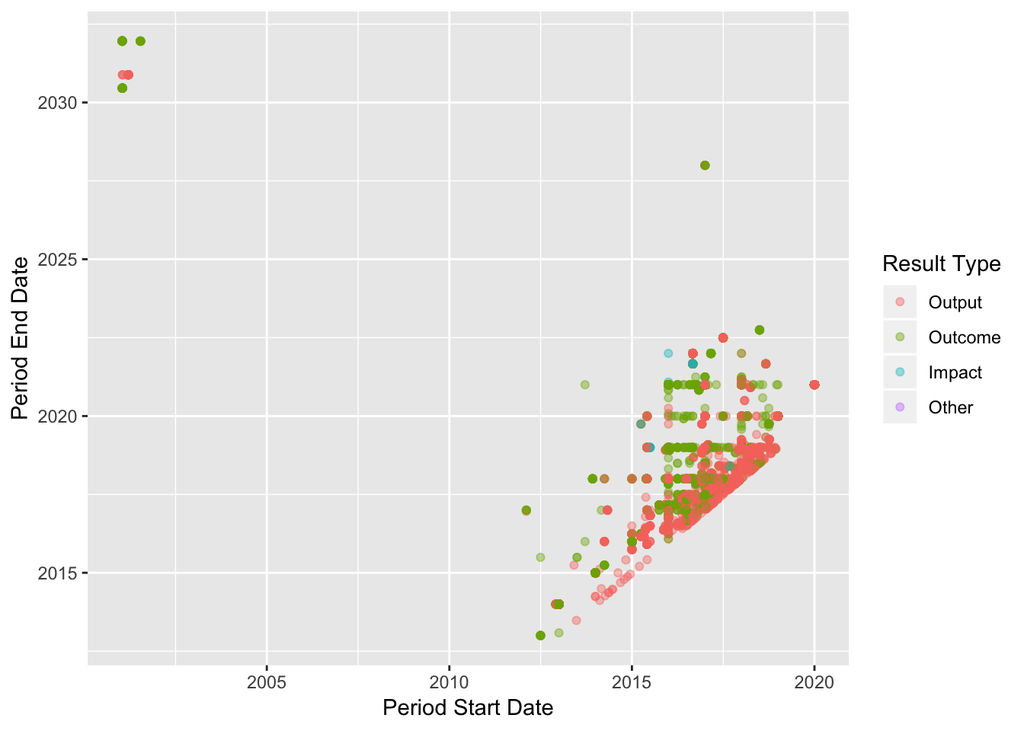

```r
df.periods %>%
  mutate(result_type = factor(cl.result.types.labels[result_type], levels = cl.result.types.labels)) %>%
  ggplot(aes(x=period_start, y=period_end)) +
  geom_point(alpha = 0.4, aes(color=result_type)) +
  labs(x="Period Start Date", y="Period End Date",color="Result Type")
```

We see that there are certain `period` which has very long duration, mostly those periods, which end after 2030. See top-left corner of the above chart.

Lets list those periods.

#### 4.5.1.1 List of long period duration `result`

```r
df.periods %>%
  filter(year(period_end) > 2030) %>%
  left_join(df.activities.all, by=c("activity_id"="id")) %>%
  left_join(df.organizations.all, by=c("organization_id"="id")) %>%
  select(name, identifier, result_title, period_start, period_end) %>%
  mutate(iati_identifier = map_chr(identifier, get_identifier)) %>%
  group_by(name, iati_identifier) %>%
  gt() %>%
  cols_label(
    result_title = "Result Title",
    period_start = "Period Start Date",
    period_end = "Period End Date"
  ) %>%
  cols_hide(
    columns = "identifier"
  ) %>%
  tab_style(
    style = cells_styles(
      text_size = px(12)
    ),
    locations = cells_data(
      columns = everything()
    )
  )
```

| Result Title | Period Start Date | Period End Date |
| --- | --- | --- |
| Stichting CARE Nederland - NL-KVK-41158230-NLRCGT0001 |  |  |
| Interagency Strategic Agenda (ISA) as a space for dialogue for IRM | 2001-01-16 | 2031-12-20 |
| Interagency Strategic Agenda (ISA) as a space for dialogue for IRM | 2001-01-16 | 2031-12-16 |
| Interagency Strategic Agenda (ISA) as a space for dialogue for IRM | 2001-07-17 | 2031-12-17 |
| Interagency Strategic Agenda (ISA) as a space for dialogue for IRM | 2001-01-16 | 2031-12-20 |
| Interagency Strategic Agenda (ISA) as a space for dialogue for IRM | 2001-07-17 | 2031-12-17 |
| Empowerment of women in the IRM approach | 2001-01-16 | 2031-12-20 |
| Empowerment of women in the IRM approach | 2001-07-17 | 2031-12-17 |
| Empowerment of women in the IRM approach | 2001-01-16 | 2031-12-20 |
| Empowerment of women in the IRM approach | 2001-01-16 | 2031-12-16 |
| Empowerment of women in the IRM approach | 2001-07-17 | 2031-12-17 |
| Stichting CARE Nederland - NL-KVK-41158230-NLRCET0001 |  |  |
| Improving food security through the management of agriculture, livestock and rangeland practices | 2001-01-16 | 2031-12-20 |
| Improving food security through the management of agriculture, livestock and rangeland practices | 2001-01-16 | 2031-12-16 |
| Improving food security through the management of agriculture, livestock and rangeland practices | 2001-07-17 | 2031-12-17 |
| Investment strategies are based on the Environmental Impact Assessment | 2001-01-16 | 2031-12-20 |
| Investment strategies are based on the Environmental Impact Assessment | 2001-01-16 | 2031-12-16 |
| Investment strategies are based on the Environmental Impact Assessment | 2001-07-17 | 2031-12-17 |
| Stichting CARE Nederland - NL-KVK-41158230-NLRCID0001 |  |  |
| Gender-sensitive community-based development plans incorporate and fund IRM initiatives | 2001-01-16 | 2031-12-20 |
| Gender-sensitive community-based development plans incorporate and fund IRM initiatives | 2001-01-16 | 2031-12-16 |
| Gender-sensitive community-based development plans incorporate and fund IRM initiatives | 2001-07-17 | 2031-12-17 |
| Gender-sensitive community-based development plans incorporate and fund IRM initiatives | 2001-01-16 | 2031-12-20 |
| Gender-sensitive community-based development plans incorporate and fund IRM initiatives | 2001-01-16 | 2031-12-16 |
| Gender-sensitive community-based development plans incorporate and fund IRM initiatives | 2001-07-17 | 2031-12-17 |
| Gender-sensitive community-based development plans incorporate and fund IRM initiatives | 2001-01-16 | 2031-12-20 |
| Gender-sensitive community-based development plans incorporate and fund IRM initiatives | 2001-01-16 | 2031-12-16 |
| Gender-sensitive community-based development plans incorporate and fund IRM initiatives | 2001-07-17 | 2031-12-17 |
| Stichting CARE Nederland - NL-KVK-41158230-NLRCPH0002 |  |  |
| Key stakeholders mainstream Integrated Risk Management in inclusive planning guidelines | 2001-01-16 | 2031-12-20 |
| Key stakeholders mainstream Integrated Risk Management in inclusive planning guidelines | 2001-01-16 | 2031-12-16 |
| Key stakeholders mainstream Integrated Risk Management in inclusive planning guidelines | 2001-07-17 | 2031-12-17 |
| Key stakeholders mainstream Integrated Risk Management in inclusive planning guidelines | 2001-01-16 | 2031-12-20 |
| Key stakeholders mainstream Integrated Risk Management in inclusive planning guidelines | 2001-01-16 | 2031-12-16 |
| Key stakeholders mainstream Integrated Risk Management in inclusive planning guidelines | 2001-07-17 | 2031-12-17 |
| Key stakeholders mainstream Integrated Risk Management in inclusive planning guidelines | 2001-01-16 | 2031-12-20 |
| Key stakeholders mainstream Integrated Risk Management in inclusive planning guidelines | 2001-01-16 | 2031-12-16 |
| Key stakeholders mainstream Integrated Risk Management in inclusive planning guidelines | 2001-07-17 | 2031-12-17 |
| Stichting CARE Nederland - NL-KVK-41158230-NLRCUG0001 |  |  |
| Integrated risk management approach is mainstreamed in development policies re. climate change | 2001-01-16 | 2031-12-20 |
| Integrated risk management approach is mainstreamed in development policies re. climate change | 2001-01-16 | 2031-12-16 |
| Integrated risk management approach is mainstreamed in development policies re. climate change | 2001-07-17 | 2031-12-17 |

It’s only “Stichting CARE Nederland” that seems to have longer periods duration. We can verify those numbers from the [XML file](http://preview.iatistandard.org/index.php?url=https%3A//aidstream.org/files/xml/carenederland-activities.xml) as well. It’s worth to verify these dates at least once to ensure that we are projecting the right data to the audience at large.

### 4.5.2 `period/target` vs `period/actual`

Lets see how many `target` and `actual` values are present in `period`.

```r
df.periods %>%
  mutate(is_target_present = !is.na(period_target),
         is_actual_present = !is.na(period_actual)) %>%
  group_by(is_target_present, is_actual_present) %>%
  count() %>%
  ungroup() %>%
  spread(is_actual_present, n) %>%
  gt() %>%
  tab_spanner(
    label = "Is Actual Present?",
    columns = vars(FALSE, TRUE)
  ) %>%
  cols_label(
    is_target_present = "Is Target Present?"
  ) %>%
  tab_style(
    style = cells_styles(
      text_size = px(12)
    ),
    locations = cells_data(
      columns = everything()
    )
  )
```

| Is Target Present? | Is Actual Present? |  |
| --- | --- | --- |
|  | FALSE | TRUE |
| FALSE | 3011 | 3928 |
| TRUE | 2899 | 5910 |

Lets narrow our analysis to unit quantitative measure only, i.e. `indicator/measure` = 1.

```r
df.periods %>%
  filter(indicator_measure==1) %>%
  mutate(is_target_present = !is.na(period_target),
         is_actual_present = !is.na(period_actual)) %>%
  group_by(is_target_present, is_actual_present) %>%
  count() %>%
  spread(is_actual_present, n) %>%
  ungroup() %>%
  gt() %>%
  tab_spanner(
    label = "Is Actual Present?",
    columns = vars(FALSE, TRUE)
  ) %>%
  cols_label(
    is_target_present = "Is Target Present?"
  ) %>%
  tab_style(
    style = cells_styles(
      text_size = px(12)
    ),
    locations = cells_data(
      columns = everything()
    )
  )
```

| Is Target Present? | Is Actual Present? |  |
| --- | --- | --- |
|  | FALSE | TRUE |
| FALSE | 2590 | 3069 |
| TRUE | 2320 | 4958 |

Now lets plot 4958 points of `actual` and `target` values in scatterplot.

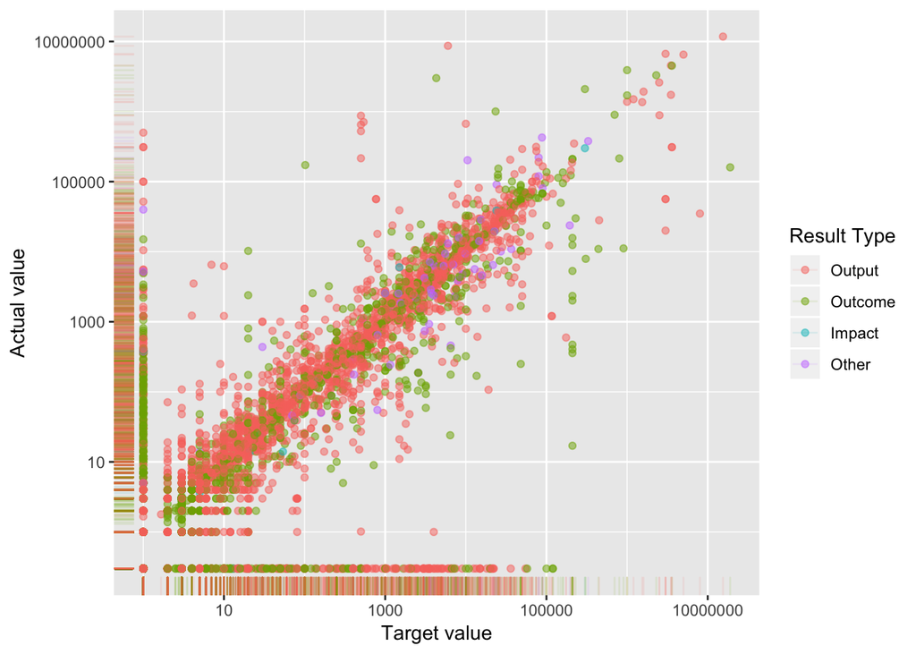

```r
df.periods %>%
  filter(indicator_measure==1) %>%
  mutate(is_target_present = !is.na(period_target),
         is_actual_present = !is.na(period_actual)) %>%
  filter(is_target_present == TRUE & is_actual_present == TRUE) %>%
  mutate(result_type = factor(cl.result.types.labels[result_type], levels = cl.result.types.labels)) %>%
  ggplot(aes(x=as.numeric(period_target), y=as.numeric(period_actual), color=result_type)) +
  geom_point(alpha=0.5) +
  geom_rug(alpha=0.1) +
  scale_y_log10(oob=squish_infinite) +
  scale_x_log10(oob=squish_infinite) +
  labs(x = "Target value", y="Actual value",color="Result Type")
```

There’s lot of points.

Lets see these points separately for each `result/type`

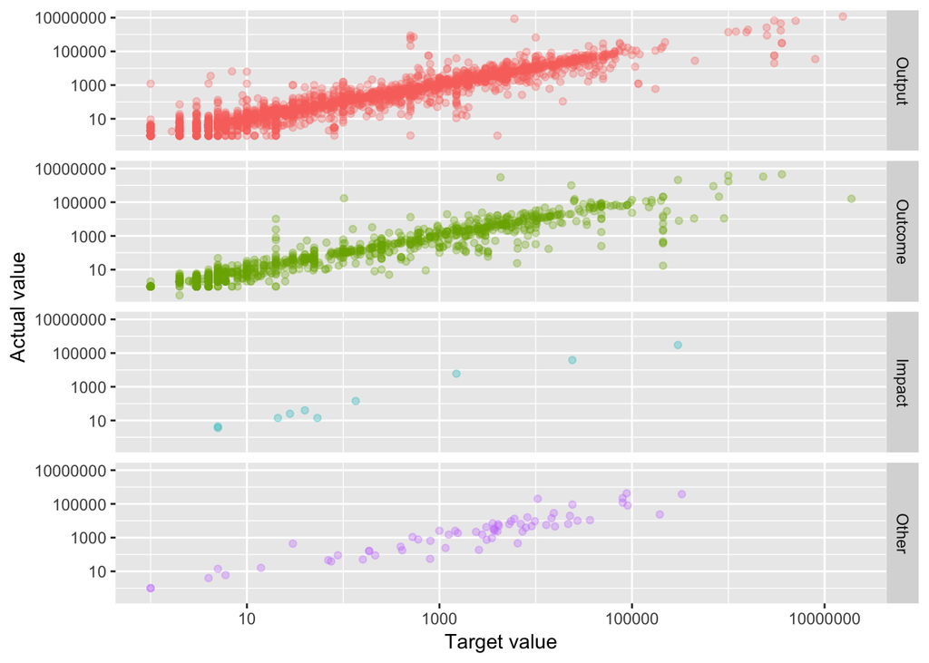

```r
df.periods %>%
  filter(indicator_measure==1) %>%
  mutate(is_target_present = !is.na(period_target),
         is_actual_present = !is.na(period_actual)) %>%
  filter(is_target_present == TRUE & is_actual_present == TRUE) %>%
  mutate(period_target_number = as.numeric(period_target),
         period_actual_number = as.numeric(period_actual)) %>%
  filter(period_target_number>0 & period_actual_number>0) %>%
  mutate(percent_change = (period_actual_number-period_target_number)/period_target_number) %>%
  mutate(result_type = factor(cl.result.types.labels[result_type], levels = cl.result.types.labels)) %>%
  ggplot(aes(x=period_target_number, y=period_actual_number, color=result_type)) +
  geom_point(alpha=0.3) +
  scale_y_log10(oob=squish_infinite) +
  scale_x_log10(oob=squish_infinite) +
  facet_grid(result_type ~ .) +
  labs(x = "Target value", y="Actual value") +
  theme(
    legend.position = "none"
  )
```

### 4.5.3 Percent change between `target` and `actual` values

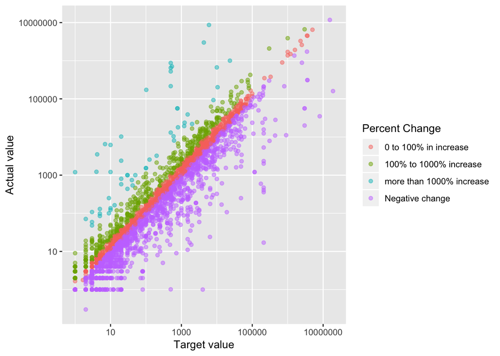

```r
df.periods %>%
  filter(indicator_measure==1) %>%
  mutate(is_target_present = !is.na(period_target),
         is_actual_present = !is.na(period_actual)) %>%
  filter(is_target_present == TRUE & is_actual_present == TRUE) %>%
  mutate(period_target_number = as.numeric(period_target),
         period_actual_number = as.numeric(period_actual)) %>%
  filter(period_target_number>0 & period_actual_number>0) %>%
  mutate(percent_change = 100*(period_actual_number-period_target_number)/period_target_number) %>%
  mutate(percent_change_bin = ifelse(percent_change >=1000, "more than 1000% increase",
                                     ifelse(percent_change >=100,
                                            "100% to 1000% increase",
                                            ifelse(percent_change <=0,
                                                   "Negative change", "0 to 100% in increase")))
         ) %>%
  ggplot(aes(x=period_target_number, y=period_actual_number, color = percent_change_bin)) +
  geom_point(alpha=0.5) +
  scale_y_log10(oob=squish_infinite) +
  scale_x_log10(oob=squish_infinite) +
  labs(x = "Target value", y = "Actual value", color = "Percent Change")
```

### 4.5.4 List of `target` and `actual` with more than 1000% increase

```r
df.periods %>%
  filter(indicator_measure==1) %>%
  left_join(df.activities.all, by=c("activity_id"="id")) %>%
  left_join(df.organizations.all, by=c("organization_id"="id")) %>%
  mutate(is_target_present = !is.na(period_target),
         is_actual_present = !is.na(period_actual)) %>%
  filter(is_target_present == TRUE & is_actual_present == TRUE) %>%
  mutate(period_target_number = as.numeric(period_target),
         period_actual_number = as.numeric(period_actual)) %>%
  filter(period_target_number>0 & period_actual_number>0) %>%
  mutate(percent_change = 100*(period_actual_number-period_target_number)/period_target_number) %>%
  filter(abs(percent_change) >= 1000) %>%
  select(name, result_title, period_target, period_actual, percent_change) %>%
  group_by(name) %>%
  gt() %>%
  cols_label(
    result_title = "Result Title",
    period_target = "Target Value",
    period_actual = "Actual Value",
    percent_change = "Percent Increase"
  ) %>%
  fmt_number(
    columns = vars(percent_change),
    decimals = 2
  ) %>%
  fmt_number(
    columns = vars(period_target, period_actual),
    decimals = 0
  ) %>%
  tab_style(
    style = cells_styles(
      text_size = px(12)
    ),
    locations = cells_data(
      columns = everything()
    )
  )
```

[output not shown]

Thank you for reading. Any questions or suggestions? Please ask me [@twitter](https://twitter.com/anjesh)